# [ggplot2](http://docs.ggplot2.org/current/index.html)

In this tutorial we will run examples and discuss how to build plots using ggplot2. We will not document the exact methods in great detail because there are already so many great tutorials on ggplot methods available online.

## Some good tutorials

- [A tutorial by Hadley Wickham](http://www.ceb-institute.org/bbs/wp-content/uploads/2011/09/handout_ggplot2.pdf)
- http://www.statmethods.net/advgraphs/ggplot2.html
- [Using qplot](http://blog.echen.me/2012/01/17/quick-introduction-to-ggplot2/)
- http://www.noamross.net/blog/2012/10/5/ggplot-introduction.html
- [Jenny Bryan’s ggplot tutorial](https://github.com/jennybc/ggplot2-tutorial)

## The basics

We will work through some examples taken from Jenny Bryans tutorial. `ggplot` is a syntax that allows you to build plot from dataframes in R. It is a stepwise method where you start with a simple plot and then add to it the features that you want.

## Load some data

We’ll use data that is in a package called `gapminder`

```r
library(ggplot2)
library(gapminder)
str(gapminder)
```

```
Classes 'tbl_df', 'tbl' and 'data.frame':   1704 obs. of  6 variables:
 $ country  : Factor w/ 142 levels "Afghanistan",..: 1 1 1 1 1 1 1 1 1 1 ...
 $ continent: Factor w/ 5 levels "Africa","Americas",..: 3 3 3 3 3 3 3 3 3 3 ...
 $ year     : int  1952 1957 1962 1967 1972 1977 1982 1987 1992 1997 ...
 $ lifeExp  : num  28.8 30.3 32 34 36.1 ...
 $ pop      : int  8425333 9240934 10267083 11537966 13079460 14880372 12881816 13867957 16317921 22227415 ...
 $ gdpPercap: num  779 821 853 836 740 ...
```

Feel free to explore the data however you see fit. Here is the basic structure of the call to `ggplot`

```r
ggplot(gapminder, aes(x = gdpPercap, y = lifeExp))
```

Above you define a plot which dataframe to plot (`gapminder`) and the variables that you would like to use on the x (`gdpPercap`) and y (`lifeExp`) axes. Note that you don’t have to use quotation marks around the variable names. But… **No graph**. You have only defined the data source for the graph so far. A good idea now is to put that definition in a new object and then start adding to it, call it the initialized plot:

```r
p <- ggplot(gapminder, aes(x = gdpPercap, y = lifeExp))
```

Now we will actually get a plot when we ask for the first layer:

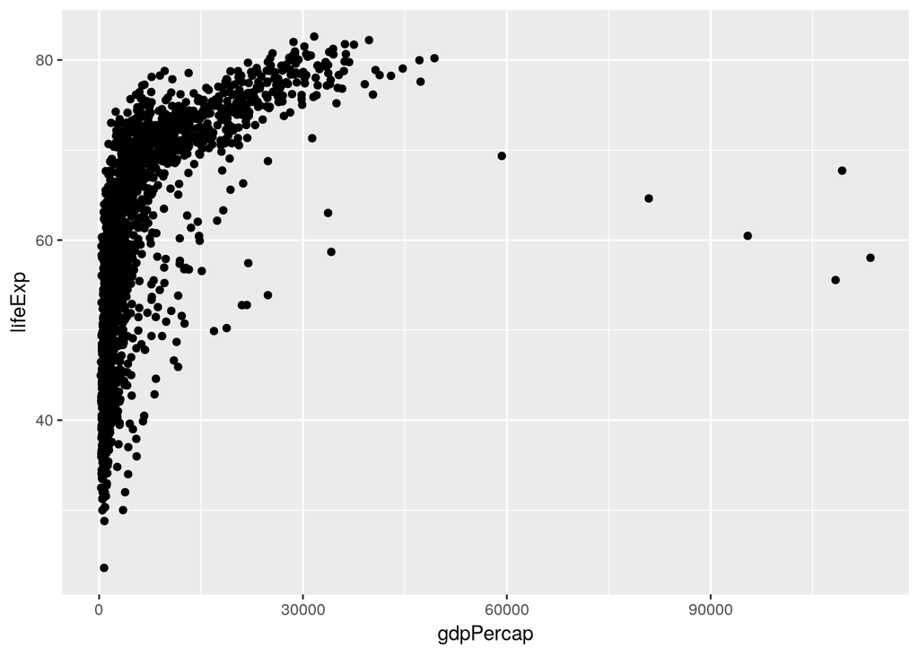

```r
p + geom_point()
```

The same thing could have been achieved by running the plot initialization with the first layer. Like this:

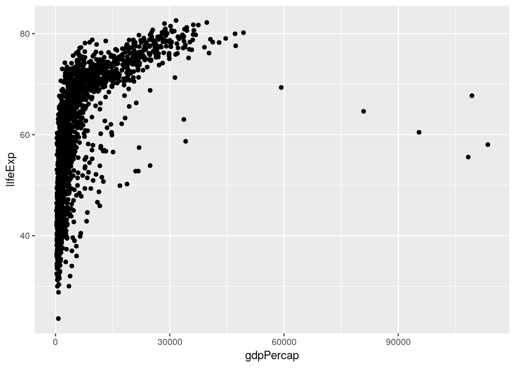

```r
ggplot(gapminder, aes(x = gdpPercap, y = lifeExp)) +
    geom_point()
```

The `ggplot` syntax is built on this pieces of the puzzle separated by the plus (`+`) operator. Like all things in R you can go to a new line whenever you like and it makes sense to do this at the `+`.

We can change the scale of the x-axis if we want:

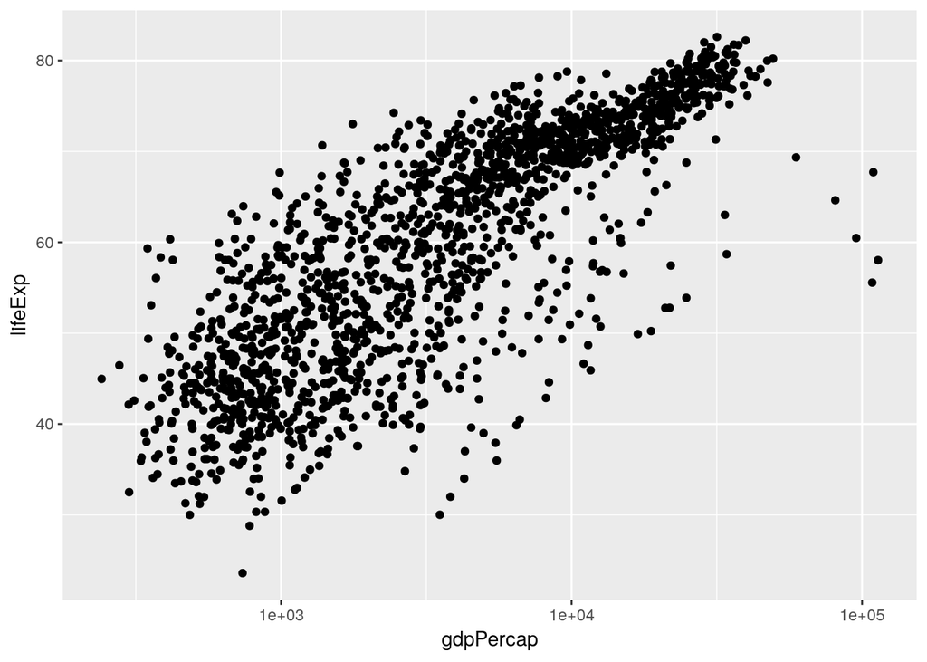

```r
p + geom_point() + scale_x_log10()
```

Then if you want to add the log scale to you plot, you can make it stick by just redefining `p`

```r
p <- p + scale_x_log10()
```

We have another variable `continent` in the dataset that we can use to colourize the points. We are added to the pre-existing definition of `aes`, with the argument `color` and the variable we want to colour by is `continent`

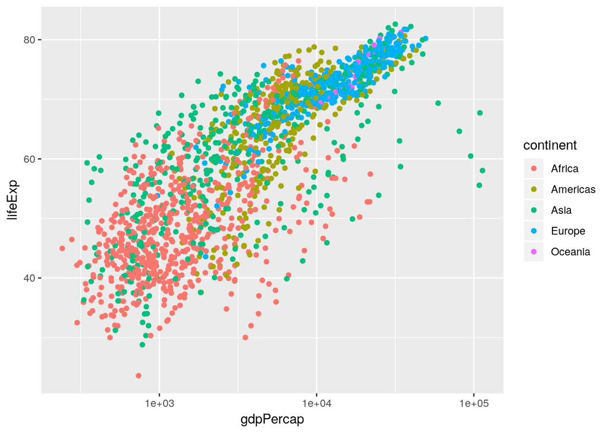

```r
p + geom_point(aes(color = continent))
```

You could also affect the transparency of the points in the `geom_point()` by doing the following to make it possible to visualize overlapping point intensity.

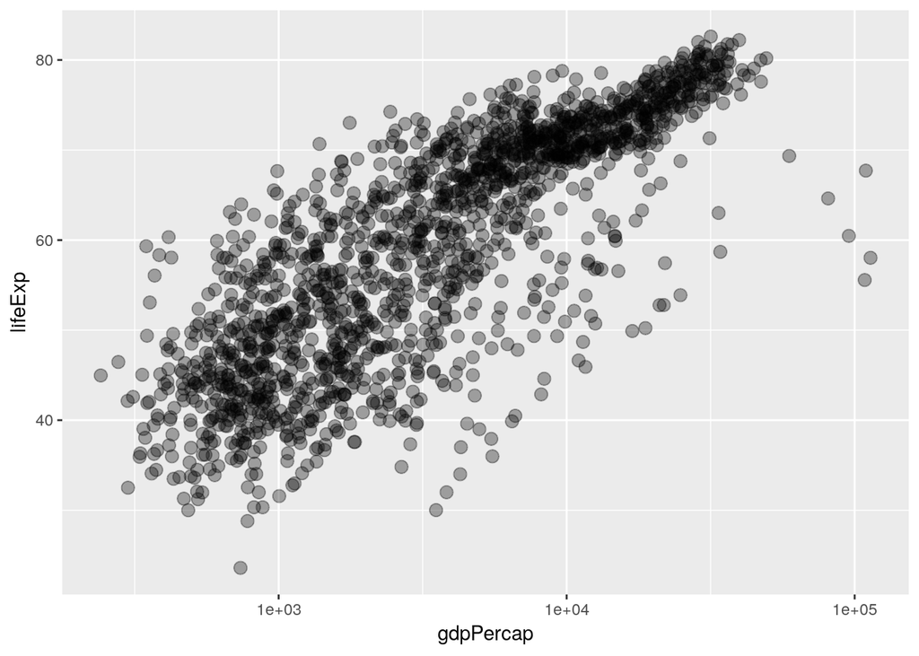

```r
p + geom_point(alpha = (1/3), size = 3)
```

You can quickly add a smooth line that represents the points as well

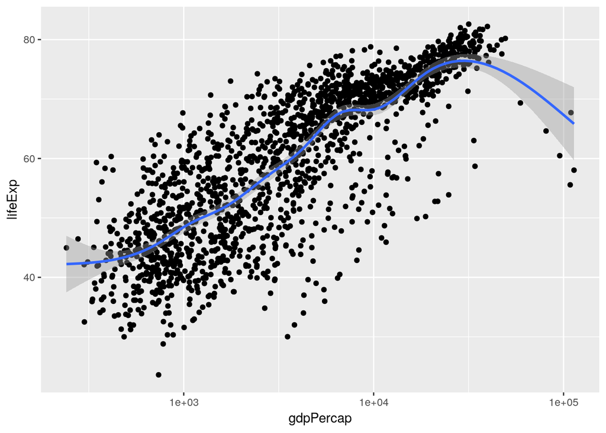

```r
p + geom_point() + geom_smooth()
```

Try these two:

```r
p + geom_point() + geom_smooth(lwd = 3, se = FALSE)
p + geom_point() + geom_smooth(lwd = 3, se = FALSE, method = "lm")
```

Try to add the continent variable back

```r
p + aes(color = continent) + geom_point() + geom_smooth(lwd = 3, se = FALSE)
```

## Facetting:

Often you need to look at parallel plots of your data, split by one of your variables. Instead of colouring the lines or points by the `continent` variable, we will split with `facet_wrap`

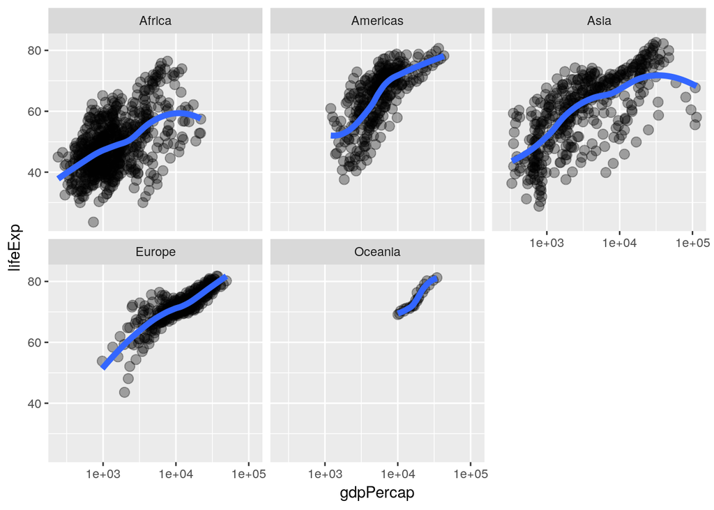

```r
p + geom_point(alpha = (1/3), size = 3) + facet_wrap(~ continent) +
  geom_smooth(lwd = 2, se = FALSE)
```

** Now you try

- Make a plot of `lifeExp` against year.
- make sub-plots, split by continent of the figure you just created
- add a fitted smooth to your plot or plots

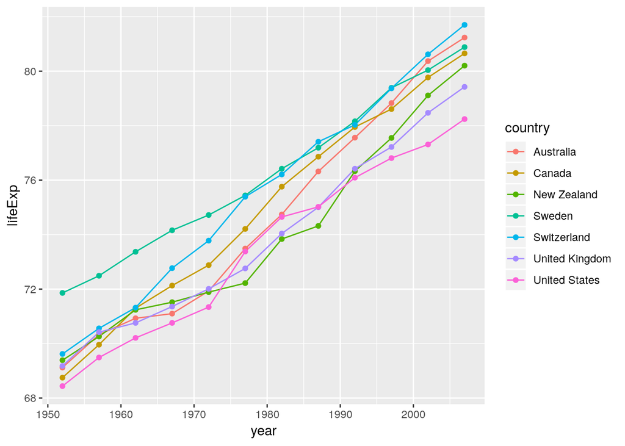

```r
jCountries <- c("United Kingdom",
                "Australia",
                "Sweden" ,
                "New Zealand",
                "United States",
                "Canada",
                "Switzerland")

gapminder2 <- subset(gapminder, country %in% jCountries)

ggplot(gapminder2,aes(x = year, y = lifeExp, color = country)) +
    geom_line() +
    geom_point()
```

# Now you try again.

- Load the “pig_adg_.csv” dataset and plot something interesting from it:
  - Use `read.csv` to read in the data
  - Think about which variables you can plot and which you could colour by or use for “faceting”
  - Try “facet.grid” with `sex` and `lu` as the grid.